# Homework #2: Resampling

Jie Tang

Due: Tue Feb 15 | 10:30 am

**SYS 6018 | Spring 2022 | University of Virginia**

# Required R packages and Directories

```r
data.dir = 'https://mdporter.github.io/SYS6018/data/' # data directory
library(R6018)     # functions for SYS-6018
library(tidyverse) # functions for data manipulation
```

# Problem 1: Bootstrapping

Bootstrap resampling can be used to quantify the uncertainty in a fitted curve.

## a. Create a set of functions to generate data from the following distributions:

$$\begin{align*}
X &\sim \mathcal{U}(0, 2) \qquad \text{Uniform in $[0,2]$}\\
Y &= 1 + 2x + 5\sin(5x) + \epsilon \\
\epsilon &\sim \mathcal{N}(0,\, \sigma=2.5)
\end{align*}$$

```r
#function sets
fun_X <- function(n) runif(n,0,2)
f <- function(x) 1 + 2*x + 5*sin(5*x)
fun_Y <- function(x){
  n = length(x)
  f(x) + rnorm(n, 0, 2.5)
}
```

## b. Simulate $n=100$ realizations from these distributions. Produce a scatterplot and draw the true regression line $f(x) = E[Y \mid X=x]$. Use `set.seed(211)` prior to generating the data.

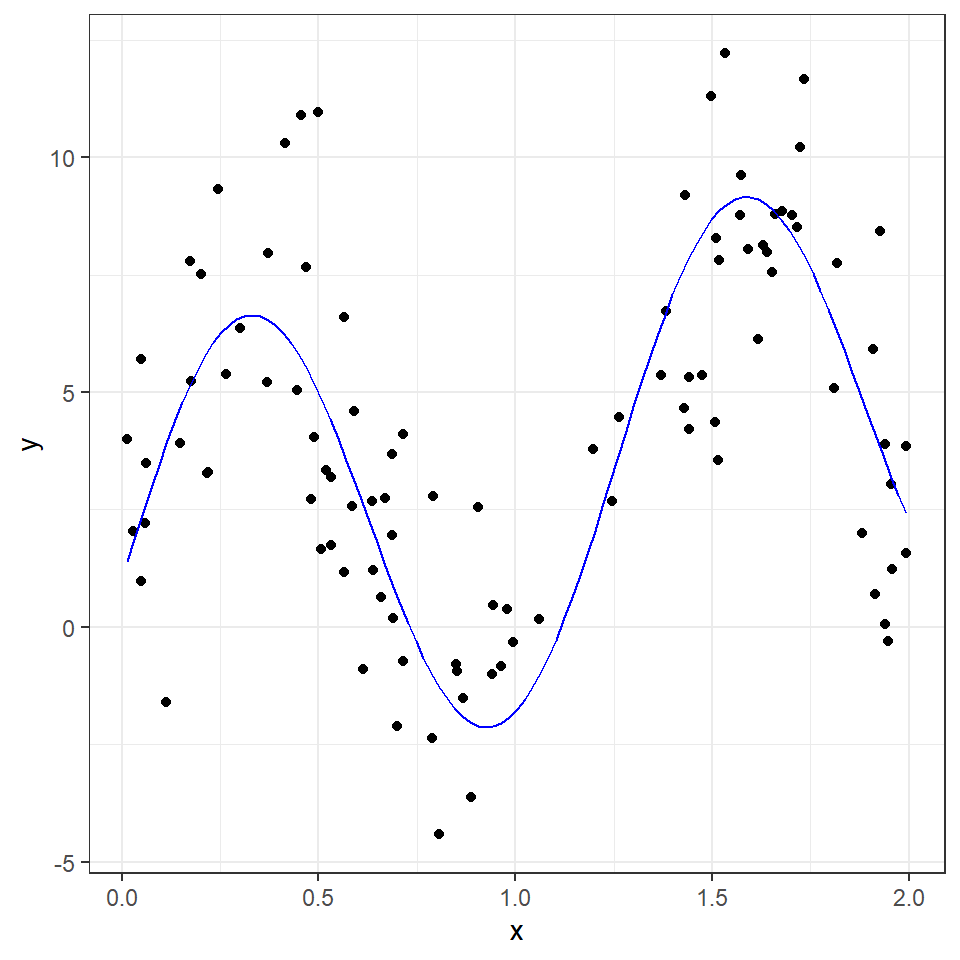

```r
set.seed(211)
#setting
n = 100

#generate data
x = fun_X(n)
y = fun_Y(x)
data_train = tibble(x,y)
#scatter plot and line
ggplot(tibble(x,y), aes(x,y)) +
  geom_point() + geom_function(fun=f, color="blue")
```

## c. Fit a 5th degree polynomial. Produce a scatterplot and draw the *estimated* regression curve.

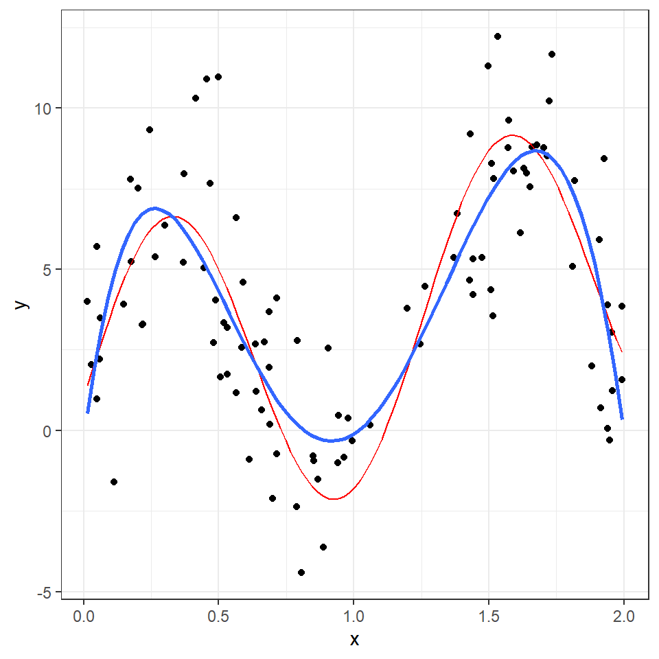

```r
#fit a 5-th polynomial model
fit5 = lm(y~poly(x, 5))

#-- Make Estimates over range of x values
xseq = seq(0, 2, length=100)
yhat = predict(fit5, tibble(xseq))

data = tibble(x=xseq, y=yhat)

ggplot(tibble(x,y), aes(x, y)) +
  geom_point() +
  geom_point() + geom_function(fun=f, color="red") +
  geom_smooth(method="lm", formula="y~poly(x,5)", se=FALSE)
```

- Set the seed (use `set.seed(212)`) so your results are reproducible.
- Produce a scatterplot and add the 200 bootstrap curves

```r
#-- Bootstrap Distribution
eval.pts = tibble(seq(0, 2, length=100))

M = 200                      # number of bootstrap samples
beta = list()                      # initialize list for test statistics
set.seed(212)                # set random seed
YHAT = matrix(NA, nrow(eval.pts), 200)
for(m in 1:M){
  #- sample from empirical distribution
  ind = sample(n, replace=TRUE)    # sample indices with replacement
  data.boot = data_train[ind,]     # bootstrap sample
  #- fit regression model
  m.boot = lm(y~poly(x, 5), data=data.boot) # fit simple OLS
  #- save test statistics
  beta[[m]] = broom::tidy(m.boot) %>% select(term, estimate)
  #make predictions
  YHAT[,m] = predict(m.boot, eval.pts)
  #draw plot
  #ggplot(tibble(x,y), aes(x, y)) +
  #geom_point() + geom_smooth(method="lm", data=data_train, formula="y~poly(x,5)", se=FALSE)

}

#-- Convert to tibble and plot
data_fit = as_tibble(YHAT) %>% # convert matrix to tibble
  bind_cols(eval.pts) %>% # add the eval points
  pivot_longer(-x, names_to="simulation", values_to="y") # convert to long format
```

[output not shown]

[output not shown]

## e. Calculate the pointwise 95% confidence intervals from the bootstrap samples. That is, for each $x \in {\rm eval.pts}$, calculate the upper and lower limits such that only 5% of the curves fall outside the interval at $x$.

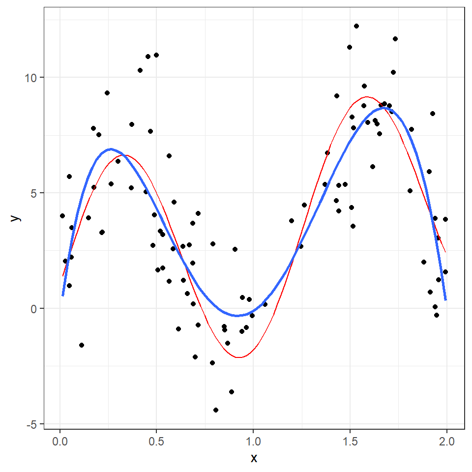

```r
#
#

for(m in 1:M){
  #- sample from empirical distribution
  ind = sample(n, replace=TRUE)    # sample indices with replacement
  data.boot = data_train[ind,]
  count = length(data.boot$x[!duplicated(data.boot$x)])
  p = count/100
  lower_bound = p - 2*sqrt(p*(1-p)/100)
  upper_bound = p + 2*sqrt(p*(1-p)/100)
  interval = c(lower_bound, upper_bound)
}

ggplot(tibble(x,y), aes(x, y)) +
  geom_point() +
  geom_point() + geom_function(fun=f, color="red") +
  geom_smooth(method="lm", formula="y~poly(x,5)", se=FALSE)
```

```r
#ggplot(data_train, aes(x,y)) +
#geom_smooth(method='lm',
#formula=as.formula('y~poly(x, 5)')) +
#geom_line(data=data_fit, color="red", alpha=.05, aes(group=simulation)) +
#geom_point()
```

# Problem 2: V-Fold cross-validation with $k$ nearest neighbors

Run 10-fold cross-validation on the data generated in part 1b to select the optimal $k$ in a k-nearest neighbor (kNN) model. Then evaluate how well cross-validation performed by evaluating the performance on a large test set. The steps below will guide you.

## a. Use $10$-fold cross-validation to find the value of $k$ (i.e., neighborhood size) that provides the smallest cross-validated MSE using a kNN model.

- Search over $k=3,4,\ldots, 50$.
- Use `set.seed(221)` prior to generating the folds to ensure the results are replicable.
- Show the following:
  - the optimal $k$ (as determined by cross-validation)
  - the corresponding estimated MSE
  - produce a plot with $k$ on the x-axis and the estimated MSE on the y-axis (optional: add 1-standard error bars).
- Notation: *v*-fold cross-validation; *k*-nearest neighbor. Don’t get yourself confused.

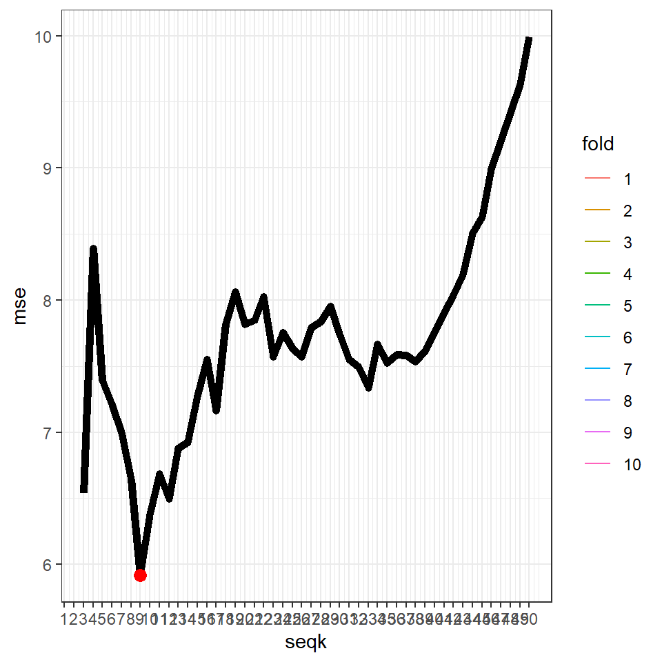

```r
library(FNN)
set.seed(221)
n = 100
#loop for knn
knn_eval <- function(data_fit, data_eval, seqk){
  MSE = numeric(length(df))
  for(i in 1:length(seqk)) {
    seqk.i = seqk[i]
    knn = knn.reg(data_fit[,'x', drop=FALSE],
                y = data_fit$y,
                test=data_fit[,'x', drop=FALSE],
                k=seqk.i)

    edf = nrow(data_fit)/seqk.i        # effective dof (edof)
    r = data_fit$y-knn$pred        # residuals on training data
    mse.train = mean(r^2)            # training MSE
    knn.test = knn.reg(data_fit[,'x', drop=FALSE],
                     y = data_fit$y,
                     test=data_eval[,'x', drop=FALSE],
                     k=seqk.i)
    r.test = data_eval$y-knn.test$pred # residuals on test data
    mse.test = mean(r.test^2)          # test MSE

    tibble(k=seqk.i, edf=edf, mse.train, mse.test)
    MSE[i] = mse.test
  }
  tibble(seqk, mse=MSE)
}

n.holdout = 10 # size of hold-out set
holdout = sample(n, size=n.holdout) # indices to include in holdout set

Kseq = seq(3, 50, by=1) # set complexity (edf) values

#results = knn_eval(
#  data_fit = slice(data_train, -holdout),
#  data_eval = slice(data_train, holdout),
#  df = DF
#)

n = nrow(data_train) # number of training observations
n.folds = 10 # number of folds for cross-validation

#loop for v-fold cross validation
all_results = tibble()
fold = sample(rep(1:n.folds, length=n))
for(j in 1:n.folds){
  val = which(fold == j)
  train = which(fold != j)
  n.val = length(val)
  results = knn_eval(
    data_fit = slice(data_train, -holdout),
    data_eval = slice(data_train, holdout),
    seqk = Kseq
    ) %>%
    mutate(fold = j, n.val)
  all_results = bind_rows(all_results, results)
}
##########
#SOMETHING WRONG
##########
all_results %>% mutate(fold = factor(fold)) %>%
ggplot(aes(seqk, mse)) +
geom_line(aes(color=fold)) +
geom_point(data=. %>% group_by(fold) %>% slice_min(mse, n=1), color="blue") +
geom_line(data = . %>% group_by(seqk) %>% summarize(mse = mean(mse)), size=2) +
geom_point(data = . %>% group_by(seqk) %>% summarize(mse = mean(mse)) %>%
slice_min(mse, n=1), size=3, color="red") +
scale_x_continuous(breaks = seq(0, 50, by=1))
```

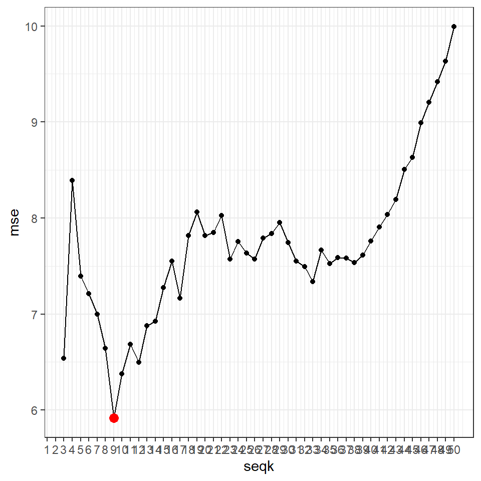

```r
ggplot(all_results, aes(seqk, mse)) +
geom_point() + geom_line() +
geom_point(data = . %>% slice_min(mse, n=1), color="red", size=3) +
scale_x_continuous(breaks = seq(0, 50, by=1))
```

## b. The $k$ (number of neighbors) in a kNN model determines the effective degrees of freedom *edf*. What is the optimal *edf*? Be sure to use the correct sample size when making this calculation. Produce a plot similar to that from part *a*, but use *edf* (effective degrees of freedom) on the x-axis.

The effective degrees of freedom or edf for a knn model is n/k. In this case, under the 10-fold cross validation, each training step uses 9 fold from whole data. So, I think n should be 90. From above figure, I think optimal k should be 9. Therefore, optimal edf should be 90/9 = 10.

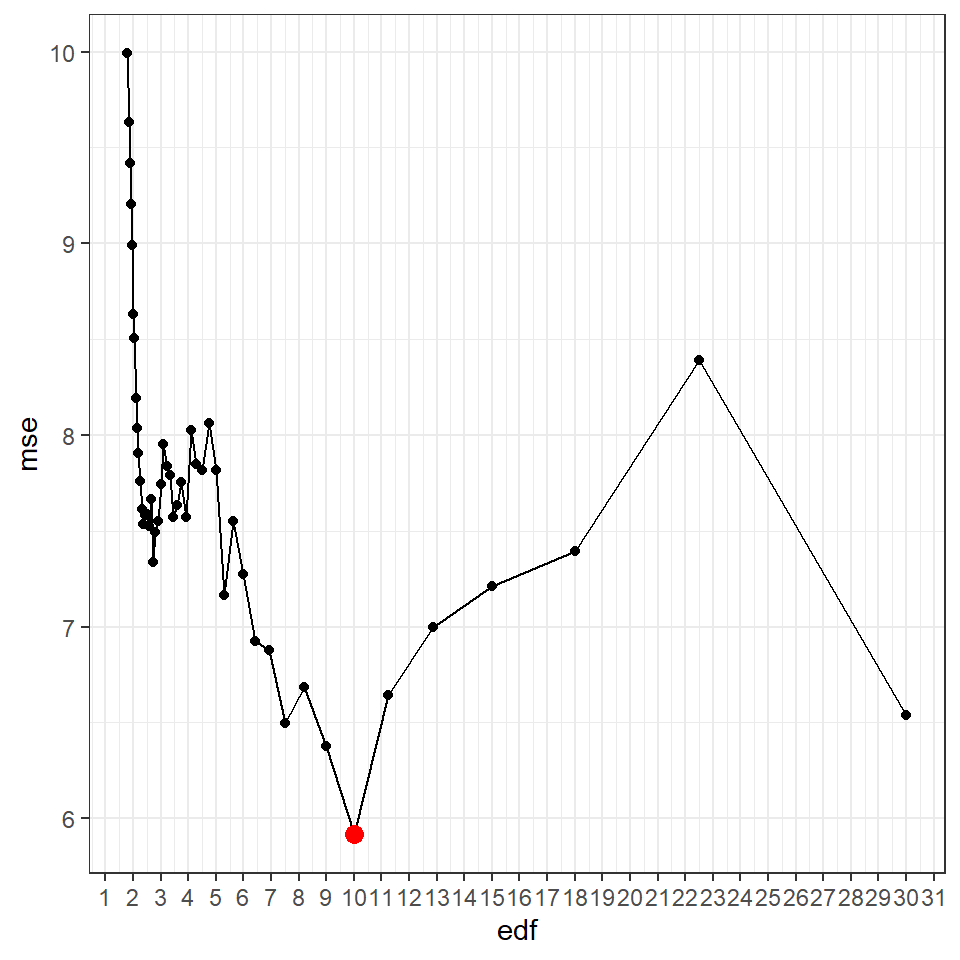

```r
all_results$edf <- 90 / all_results$seqk
ggplot(all_results, aes(edf, mse)) +
geom_point() + geom_line() +
geom_point(data = . %>% slice_min(mse, n=1), color="red", size=3) +
scale_x_continuous(breaks = seq(0, 50, by=1))
```

## c. After running cross-validation, a final model fit from *all* of the training data needs to be produced to make predictions. What value of $k$ would you choose? Why?

9. Because from the above figure, we can see that when k is 9, the cross validation has the lowest mse value.

## d. Now we will see how well cross-validation performed. Simulate a test data set of $50000$ observations from the same distributions. Use `set.seed(223)` prior to generating the test data.

- Fit a set of kNN models, using the full training data, and calculate the mean squared error (MSE) on the test data for each model. Use the same $k$ values in *a*.
- Report the optimal $k$, the corresponding *edf*, and MSE based on the test set.

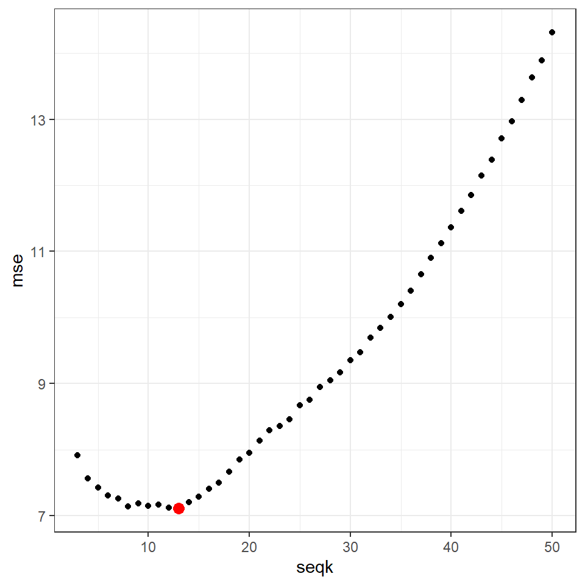

```r
#setting
n = 50000
set.seed(223)
#generate data
x = fun_X(n)
y = fun_Y(x)
d_test_data = tibble(x,y)

res <- knn_eval(data_train, d_test_data, seq(3, 50, by=1))
#res
ggplot(res, aes(seqk, mse)) + geom_point() + geom_point(data = . %>% slice_min(mse, n=1), color="red", size=3)
```

```r
min_mse = min(res$seqk)
print(min_mse)
```

```
#> [1] 3
```

## e. Plot both the cross-validation estimated and (true) error calculated from the test data on the same plot. See Figure 5.6 in ISL (pg 182) as a guide.

- Produce two plots: one with $k$ on the x-axis and one with *edf* on the x-axis.
- Each plot should have two lines: one from part *a* and one from part *d*

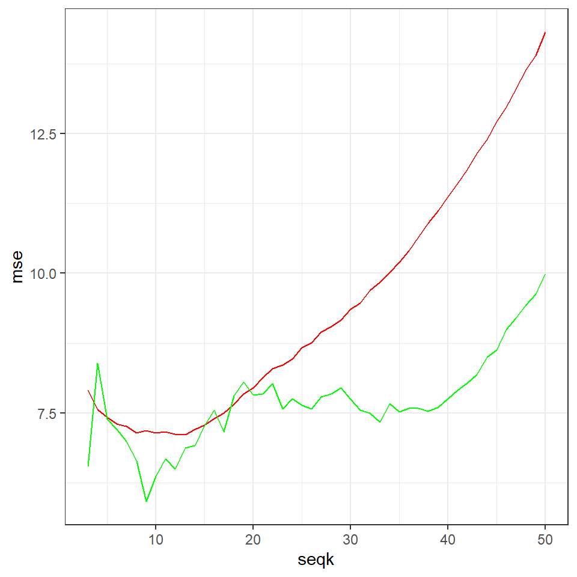

```r
#Green line is cv and red line is error calculated
ggplot(data = res, aes(seqk, mse)) +
  geom_line(data=res, color='red') +
  geom_line(data=all_results, color='green')
```

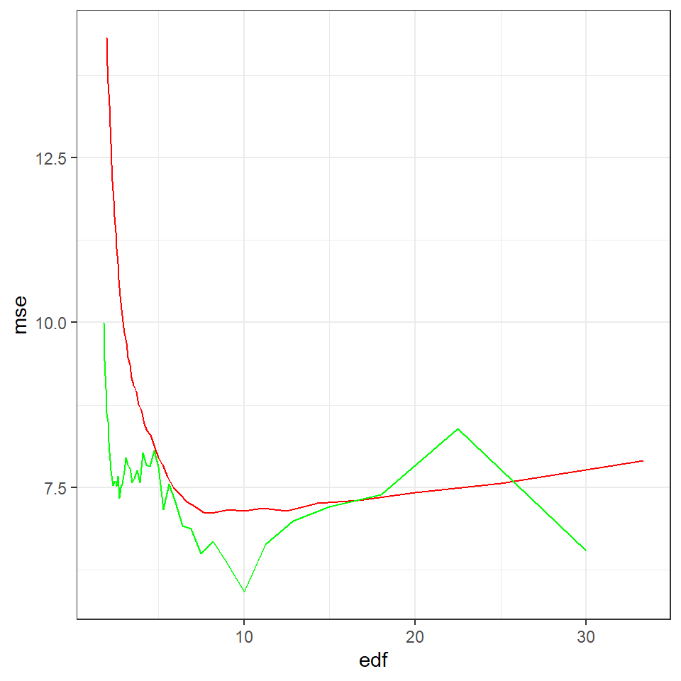

```r
res$edf <- 100 / res$seqk
ggplot(data = res, aes(edf, mse)) +
  geom_line(data=res, color='red') +
  geom_line(data=all_results, color='green')
```